# Assignment2-R

## Assignment 2 - Simple and Multiple Linear Regression (I)

### Overview of the steps

1. Load the data and get an overview of the data
2. Perform simple linear regressions
3. Use the simple linear regression models
4. Perform multiple linear regressions
5. Use the multiple linear regression model

### Steps in detail

#### Load the data and get an overview of the data

Load the data file `Boston.csv`.

```python
import pandas as pd
from IPython.display import display, Markdown
import numpy as np
import matplotlib.pyplot as plt
%matplotlib notebook
import statsmodels.api as sm
from statsmodels.formula.api import ols
import scipy
import seaborn as sns
default_figsize=(8, 6)


boston_df = pd.read_csv('../ISLR/data/Boston.csv', index_col=[0])
```

Display the number of predictors (including the response medv) and their names:

```python
print(len(boston_df.columns))
print(boston_df.columns)
```

```
14
Index(['crim', 'zn', 'indus', 'chas', 'nox', 'rm', 'age', 'dis', 'rad', 'tax',
       'ptratio', 'black', 'lstat', 'medv'],
      dtype='object')
```

Print a statistic summary of the predictors and the response `medv`:

```python
boston_df.describe(include='all')
```

|  | crim | zn | indus | chas | nox | rm | age | dis | rad | tax | ptratio | black | lstat | medv |
| --- | --- | --- | --- | --- | --- | --- | --- | --- | --- | --- | --- | --- | --- | --- |
| count | 506.000000 | 506.000000 | 506.000000 | 506.000000 | 506.000000 | 506.000000 | 506.000000 | 506.000000 | 506.000000 | 506.000000 | 506.000000 | 506.000000 | 506.000000 | 506.000000 |
| mean | 3.613524 | 11.363636 | 11.136779 | 0.069170 | 0.554695 | 6.284634 | 68.574901 | 3.795043 | 9.549407 | 408.237154 | 18.455534 | 356.674032 | 12.653063 | 22.532806 |
| std | 8.601545 | 23.322453 | 6.860353 | 0.253994 | 0.115878 | 0.702617 | 28.148861 | 2.105710 | 8.707259 | 168.537116 | 2.164946 | 91.294864 | 7.141062 | 9.197104 |
| min | 0.006320 | 0.000000 | 0.460000 | 0.000000 | 0.385000 | 3.561000 | 2.900000 | 1.129600 | 1.000000 | 187.000000 | 12.600000 | 0.320000 | 1.730000 | 5.000000 |
| 25% | 0.082045 | 0.000000 | 5.190000 | 0.000000 | 0.449000 | 5.885500 | 45.025000 | 2.100175 | 4.000000 | 279.000000 | 17.400000 | 375.377500 | 6.950000 | 17.025000 |
| 50% | 0.256510 | 0.000000 | 9.690000 | 0.000000 | 0.538000 | 6.208500 | 77.500000 | 3.207450 | 5.000000 | 330.000000 | 19.050000 | 391.440000 | 11.360000 | 21.200000 |
| 75% | 3.677083 | 12.500000 | 18.100000 | 0.000000 | 0.624000 | 6.623500 | 94.075000 | 5.188425 | 24.000000 | 666.000000 | 20.200000 | 396.225000 | 16.955000 | 25.000000 |
| max | 88.976200 | 100.000000 | 27.740000 | 1.000000 | 0.871000 | 8.780000 | 100.000000 | 12.126500 | 24.000000 | 711.000000 | 22.000000 | 396.900000 | 37.970000 | 50.000000 |

Display the number of data points:

```python
len(boston_df)
```

```
506
```

Display the data in a table:

> Top 20 rows are shown.

```python
n = 20
display(boston_df.info(verbose=True))
display(boston_df.head(n))
```

```
<class 'pandas.core.frame.DataFrame'>
Int64Index: 506 entries, 1 to 506
Data columns (total 14 columns):
 #   Column   Non-Null Count  Dtype
---  ------   --------------  -----
 0   crim     506 non-null    float64
 1   zn       506 non-null    float64
 2   indus    506 non-null    float64
 3   chas     506 non-null    int64
 4   nox      506 non-null    float64
 5   rm       506 non-null    float64
 6   age      506 non-null    float64
 7   dis      506 non-null    float64
 8   rad      506 non-null    int64
 9   tax      506 non-null    int64
 10  ptratio  506 non-null    float64
 11  black    506 non-null    float64
 12  lstat    506 non-null    float64
 13  medv     506 non-null    float64
dtypes: float64(11), int64(3)
memory usage: 59.3 KB
```

```
None
```

|  | crim | zn | indus | chas | nox | rm | age | dis | rad | tax | ptratio | black | lstat | medv |
| --- | --- | --- | --- | --- | --- | --- | --- | --- | --- | --- | --- | --- | --- | --- |
| 1 | 0.00632 | 18.0 | 2.31 | 0 | 0.538 | 6.575 | 65.2 | 4.0900 | 1 | 296 | 15.3 | 396.90 | 4.98 | 24.0 |
| 2 | 0.02731 | 0.0 | 7.07 | 0 | 0.469 | 6.421 | 78.9 | 4.9671 | 2 | 242 | 17.8 | 396.90 | 9.14 | 21.6 |
| 3 | 0.02729 | 0.0 | 7.07 | 0 | 0.469 | 7.185 | 61.1 | 4.9671 | 2 | 242 | 17.8 | 392.83 | 4.03 | 34.7 |
| 4 | 0.03237 | 0.0 | 2.18 | 0 | 0.458 | 6.998 | 45.8 | 6.0622 | 3 | 222 | 18.7 | 394.63 | 2.94 | 33.4 |
| 5 | 0.06905 | 0.0 | 2.18 | 0 | 0.458 | 7.147 | 54.2 | 6.0622 | 3 | 222 | 18.7 | 396.90 | 5.33 | 36.2 |
| 6 | 0.02985 | 0.0 | 2.18 | 0 | 0.458 | 6.430 | 58.7 | 6.0622 | 3 | 222 | 18.7 | 394.12 | 5.21 | 28.7 |
| 7 | 0.08829 | 12.5 | 7.87 | 0 | 0.524 | 6.012 | 66.6 | 5.5605 | 5 | 311 | 15.2 | 395.60 | 12.43 | 22.9 |
| 8 | 0.14455 | 12.5 | 7.87 | 0 | 0.524 | 6.172 | 96.1 | 5.9505 | 5 | 311 | 15.2 | 396.90 | 19.15 | 27.1 |
| 9 | 0.21124 | 12.5 | 7.87 | 0 | 0.524 | 5.631 | 100.0 | 6.0821 | 5 | 311 | 15.2 | 386.63 | 29.93 | 16.5 |
| 10 | 0.17004 | 12.5 | 7.87 | 0 | 0.524 | 6.004 | 85.9 | 6.5921 | 5 | 311 | 15.2 | 386.71 | 17.10 | 18.9 |
| 11 | 0.22489 | 12.5 | 7.87 | 0 | 0.524 | 6.377 | 94.3 | 6.3467 | 5 | 311 | 15.2 | 392.52 | 20.45 | 15.0 |
| 12 | 0.11747 | 12.5 | 7.87 | 0 | 0.524 | 6.009 | 82.9 | 6.2267 | 5 | 311 | 15.2 | 396.90 | 13.27 | 18.9 |
| 13 | 0.09378 | 12.5 | 7.87 | 0 | 0.524 | 5.889 | 39.0 | 5.4509 | 5 | 311 | 15.2 | 390.50 | 15.71 | 21.7 |
| 14 | 0.62976 | 0.0 | 8.14 | 0 | 0.538 | 5.949 | 61.8 | 4.7075 | 4 | 307 | 21.0 | 396.90 | 8.26 | 20.4 |
| 15 | 0.63796 | 0.0 | 8.14 | 0 | 0.538 | 6.096 | 84.5 | 4.4619 | 4 | 307 | 21.0 | 380.02 | 10.26 | 18.2 |
| 16 | 0.62739 | 0.0 | 8.14 | 0 | 0.538 | 5.834 | 56.5 | 4.4986 | 4 | 307 | 21.0 | 395.62 | 8.47 | 19.9 |
| 17 | 1.05393 | 0.0 | 8.14 | 0 | 0.538 | 5.935 | 29.3 | 4.4986 | 4 | 307 | 21.0 | 386.85 | 6.58 | 23.1 |
| 18 | 0.78420 | 0.0 | 8.14 | 0 | 0.538 | 5.990 | 81.7 | 4.2579 | 4 | 307 | 21.0 | 386.75 | 14.67 | 17.5 |
| 19 | 0.80271 | 0.0 | 8.14 | 0 | 0.538 | 5.456 | 36.6 | 3.7965 | 4 | 307 | 21.0 | 288.99 | 11.69 | 20.2 |
| 20 | 0.72580 | 0.0 | 8.14 | 0 | 0.538 | 5.727 | 69.5 | 3.7965 | 4 | 307 | 21.0 | 390.95 | 11.28 | 18.2 |

Plot some predictors (at least two) against the response values. We choose `lstat`, `rm`, and `age`.

```python
default_alpha = .05
display(Markdown(f'#### Significance level: {default_alpha}'))

def fit_lr(x, y):
    X = sm.add_constant(x)
    return sm.OLS(y, X).fit()

def plot(x, y, xlab, ylab, mod_fit=None, alpha=default_alpha):
    fig, ax = plt.subplots(figsize=default_figsize)
    ax.plot(x, y, 'yo')
    if mod_fit:
        X = sm.add_constant(x)
        regr = mod_fit.predict(X)
        ax.plot(x, regr, 'k')
        prediction = mod_fit.get_prediction(X)
        frame = prediction.summary_frame(alpha=alpha)
        zipped = pd.concat([x, frame.mean_ci_lower, frame.mean_ci_upper], axis=1)
        zipped.sort_values(x.name, inplace=True)
        ax.fill_between(zipped[x.name], zipped[frame.mean_ci_lower.name], zipped[frame.mean_ci_upper.name], color='k', alpha=.3)
    ax.set_xlabel(xlab)
    ax.set_ylabel(ylab)
    fig.show()

def format_pearsonr(values):
    return f'R = {values[0]}, p < {values[1]}'

def plot_full(x, y, xlab, ylab):
    mod_fit = fit_lr(x, y)
    print(format_pearsonr(scipy.stats.pearsonr(x, y)))
    plot(x, y, xlab, ylab, mod_fit)
    return mod_fit
```

Significance level: 0.05

```
R = -0.737662726174015, p < 5.081103394386392e-88
```

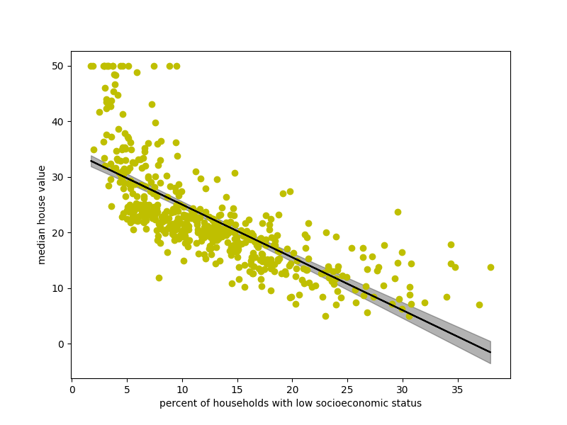

```python
lstat_mod_fit = plot_full(boston_df['lstat'], boston_df['medv'], 'percent of households with low socioeconomic status', 'median house value')
```

```
R = 0.6953599470715394, p < 2.4872288710071593e-74
```

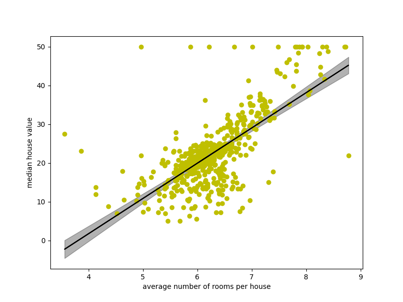

```python
rm_mod_fit = plot_full(boston_df['rm'], boston_df['medv'], 'average number of rooms per house', 'median house value')
```

```
R = -0.3769545650045963, p < 1.5699822091877261e-18
```

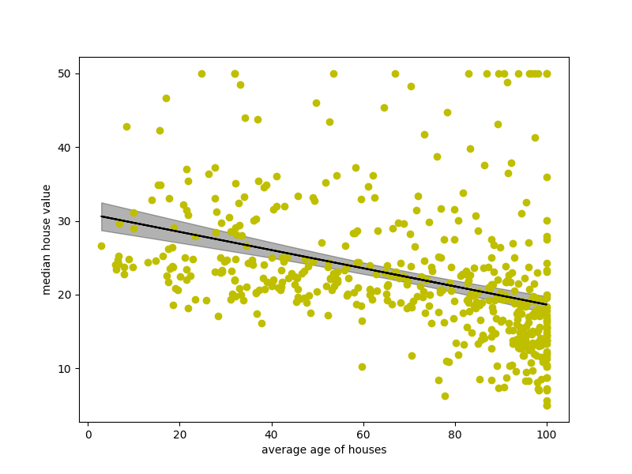

```python
age_mod_fit = plot_full(boston_df['age'], boston_df['medv'], 'average age of houses', 'median house value')
```

### 1.2.2 Perform simple linear regressions

Fit a simple linear regression model, with `medv` as the response and some (at least two) predictors individually. We choose `lstat`, `rm`, and `age`.

```python
def print_lr(mod_fit):
    print(mod_fit.params)
    print(mod_fit.summary())
    print('Residuals:', mod_fit.resid.describe())
```

```python
print_lr(lstat_mod_fit)
```

```
const    34.553841
lstat    -0.950049
dtype: float64
                            OLS Regression Results
==============================================================================
Dep. Variable:                   medv   R-squared:                       0.544
Model:                            OLS   Adj. R-squared:                  0.543
Method:                 Least Squares   F-statistic:                     601.6
Date:                Mon, 28 Mar 2022   Prob (F-statistic):           5.08e-88
Time:                        12:43:42   Log-Likelihood:                -1641.5
No. Observations:                 506   AIC:                             3287.
Df Residuals:                     504   BIC:                             3295.
Df Model:                           1
Covariance Type:            nonrobust
==============================================================================
                 coef    std err          t      P>|t|      [0.025      0.975]
------------------------------------------------------------------------------
const         34.5538      0.563     61.415      0.000      33.448      35.659
lstat         -0.9500      0.039    -24.528      0.000      -1.026      -0.874
==============================================================================
Omnibus:                      137.043   Durbin-Watson:                   0.892
Prob(Omnibus):                  0.000   Jarque-Bera (JB):              291.373
Skew:                           1.453   Prob(JB):                     5.36e-64
Kurtosis:                       5.319   Cond. No.                         29.7
==============================================================================

Notes:
[1] Standard Errors assume that the covariance matrix of the errors is correctly specified.
Residuals: count    5.060000e+02
mean     3.521821e-14
std      6.209603e+00
min     -1.516745e+01
25%     -3.989612e+00
50%     -1.318186e+00
75%      2.033701e+00
max      2.450013e+01
dtype: float64
```

```python
print_lr(rm_mod_fit)
```

```
const   -34.670621
rm        9.102109
dtype: float64
                            OLS Regression Results
==============================================================================
Dep. Variable:                   medv   R-squared:                       0.484
Model:                            OLS   Adj. R-squared:                  0.483
Method:                 Least Squares   F-statistic:                     471.8
Date:                Mon, 28 Mar 2022   Prob (F-statistic):           2.49e-74
Time:                        12:43:42   Log-Likelihood:                -1673.1
No. Observations:                 506   AIC:                             3350.
Df Residuals:                     504   BIC:                             3359.
Df Model:                           1
Covariance Type:            nonrobust
==============================================================================
                 coef    std err          t      P>|t|      [0.025      0.975]
------------------------------------------------------------------------------
const        -34.6706      2.650    -13.084      0.000     -39.877     -29.465
rm             9.1021      0.419     21.722      0.000       8.279       9.925
==============================================================================
Omnibus:                      102.585   Durbin-Watson:                   0.684
Prob(Omnibus):                  0.000   Jarque-Bera (JB):              612.449
Skew:                           0.726   Prob(JB):                    1.02e-133
Kurtosis:                       8.190   Cond. No.                         58.4
==============================================================================

Notes:
[1] Standard Errors assume that the covariance matrix of the errors is correctly specified.
Residuals: count    5.060000e+02
mean     2.359114e-14
std      6.609606e+00
min     -2.334590e+01
25%     -2.547477e+00
50%      8.976267e-02
75%      2.985532e+00
max      3.943314e+01
dtype: float64
```

```python
print_lr(age_mod_fit)
```

```
const    30.978678
age      -0.123163
dtype: float64
                            OLS Regression Results
==============================================================================
Dep. Variable:                   medv   R-squared:                       0.142
Model:                            OLS   Adj. R-squared:                  0.140
Method:                 Least Squares   F-statistic:                     83.48
Date:                Mon, 28 Mar 2022   Prob (F-statistic):           1.57e-18
Time:                        12:43:42   Log-Likelihood:                -1801.5
No. Observations:                 506   AIC:                             3607.
Df Residuals:                     504   BIC:                             3615.
Df Model:                           1
Covariance Type:            nonrobust
==============================================================================
                 coef    std err          t      P>|t|      [0.025      0.975]
------------------------------------------------------------------------------
const         30.9787      0.999     31.006      0.000      29.016      32.942
age           -0.1232      0.013     -9.137      0.000      -0.150      -0.097
==============================================================================
Omnibus:                      170.034   Durbin-Watson:                   0.613
Prob(Omnibus):                  0.000   Jarque-Bera (JB):              456.983
Skew:                           1.671   Prob(JB):                    5.85e-100
Kurtosis:                       6.240   Cond. No.                         195.
==============================================================================

Notes:
[1] Standard Errors assume that the covariance matrix of the errors is correctly specified.
Residuals: count    5.060000e+02
mean    -3.145486e-15
std      8.518650e+00
min     -1.509662e+01
25%     -5.138002e+00
50%     -1.957464e+00
75%      2.397527e+00
max      3.133759e+01
dtype: float64
```

#### Regression results interpretation of `medv` - median house value

Since the $R^{2}$ is calculated as $1 - \frac{RSS}{TSS}$, it, in simple words, shows how well the residual of each point is different against the mean residual value.

##### Against `lstat` - percent of households with low socioeconomic status

The slope is negative meaning that the function is decreasing and that there is a negative correlation. The value of the slope is close to -1 which means the slope angle is close to -45 degrees. All statements are confirmed by the chart.

The intercept equals approximately to 34.5 meaning the regression line is moved along the $y$ axis for 34 units, which is confirmed by the chart.

The Pearson correlation coefficient is approximately -0.74. This means that there is a correlation between `lstat` and `medv`. According to the value of the coefficient, most of the sample set is going to be densely inside an elliptic shape, which is prolonged along the `x` axis and turned down (negative slope). This information also mostly (except for $x$ values between 0 and 10) conforms to the chart.

The `p-value` is very small, which means there is a non-zero correlation between `lstat` and `medv`. So, the null-hypothesis that there is no correlation between `lstat` and `medv` has to be rejected.

The $R^{2}$ is 0.544, which means that the value is not too large for the model to fit too well and $R^{2}$ is not close to 0 which would mean the lack of explanation of `medv` by `lstat`.

So, according to $R^{2}$, there is a considerable degree of explanation between `medv` and `lstat`, but it is hard to tell if such value is good enough for this particular domain.

#### Against `rm` - average number of rooms per house

The slope is positive meaning that the function is increasing and that there is a positive correlation. The value of the slope is 9.1 which means a steep positive slope. All statements are confirmed by the chart.

The intercept equals approximately to -34 meaning the regression line is moved along the negative direction of $y$ axis for 34 units, which is hard to confirm by the chart, but it is plausible.

The Pearson correlation coefficient is approximately 0.7. This means that there is a correlation between `rm` and `medv`. According to the value of the coefficient, most of the sample set is going to be densely inside an elliptic shape, which is prolonged along the `x` axis and turned up (positive slope). This information also mostly (except for $x$ values between 7.5 and 9) conforms to the chart.

The `p-value` is very small, which means there is a non-zero correlation between `rm` and `medv`. So, the null-hypothesis that there is no correlation between `rm` and `medv` has to be rejected.

The $R^{2}$ is 0.484, which means that the value is not too large for the model to fit too well and $R^{2}$ is not close to 0 which would mean the lack of explanation of `medv` by `rm`.

So, according to $R^{2}$, there is a considerable degree of explanation between `medv` and `rm`, but it is hard to tell if such value is good enough for this particular domain.

#### Against `age` - average age of houses

The intercept equals approximately to 31 meaning the regression line is moved along the $y$ axis for 31 units, which is confirmed by the chart.

The Pearson correlation coefficient is approximately -0.377. This means that there is a correlation between `age` and `medv`. According to the value of the coefficient, most of the sample set is going to be not very densely inside an almost round elliptic shape, which is still slightly prolonged along the `x` axis and turned down (negative slope). It is hard to make similar conclusions from the chart.

The `p-value` is very small, which means there is a non-zero correlation between `age` and `medv`. So, the null-hypothesis that there is no correlation between `age` and `medv` has to be rejected.

The $R^{2}$ is 0.142, which means that the value is no strong explanation of `medv` by `age`.

Overall, it is unclear if there is a relation between `age` and `medv`. Perhaps, if linear regression is the best way to describe this relation.

Obtain a confidence interval for the coefficient estimates for the indivisual models

```python
def confint(mod_fit, alpha=default_alpha):
    return mod_fit.conf_int(alpha).rename(columns={0: f'{alpha * 50}%', 1: f'{100 - alpha * 50}%'})

def describe_axes(x, y):
    df = pd.concat([x, y], axis=1)
    df = df.describe()
    df.loc['max - min'] = df.loc['max'] - df.loc['min']
    return df
```

```python
display(Markdown('#### Linear Regression params:'), lstat_mod_fit.params)
display(Markdown('#### Confidence Intervals:'), confint(lstat_mod_fit))
display(Markdown('#### Axes Data Described:'), describe_axes(boston_df['lstat'], boston_df['medv']))
```

Linear Regression params:

```
const    34.553841
lstat    -0.950049
dtype: float64
```

Confidence Intervals:

|  | 2.5% | 97.5% |
| --- | --- | --- |
| const | 33.448457 | 35.659225 |
| lstat | -1.026148 | -0.873951 |

Axes Data Described:

|  | lstat | medv |
| --- | --- | --- |
| count | 506.000000 | 506.000000 |
| mean | 12.653063 | 22.532806 |
| std | 7.141062 | 9.197104 |
| min | 1.730000 | 5.000000 |
| 25% | 6.950000 | 17.025000 |
| 50% | 11.360000 | 21.200000 |
| 75% | 16.955000 | 25.000000 |
| max | 37.970000 | 50.000000 |
| max - min | 36.240000 | 45.000000 |

```python
display(Markdown('#### Linear Regression params:'), rm_mod_fit.params)
display(Markdown('#### Confidence Intervals:'), confint(rm_mod_fit))
display(Markdown('#### Axes Data Described:'), describe_axes(boston_df['rm'], boston_df['medv']))
```

Linear Regression params:

```
const   -34.670621
rm        9.102109
dtype: float64
```

Confidence Intervals:

|  | 2.5% | 97.5% |
| --- | --- | --- |
| const | -39.876641 | -29.464601 |
| rm | 8.278855 | 9.925363 |

Axes Data Described:

|  | rm | medv |
| --- | --- | --- |
| count | 506.000000 | 506.000000 |
| mean | 6.284634 | 22.532806 |
| std | 0.702617 | 9.197104 |
| min | 3.561000 | 5.000000 |
| 25% | 5.885500 | 17.025000 |
| 50% | 6.208500 | 21.200000 |
| 75% | 6.623500 | 25.000000 |
| max | 8.780000 | 50.000000 |
| max - min | 5.219000 | 45.000000 |

```python
display(Markdown('#### Linear Regression params:'), age_mod_fit.params)
display(Markdown('#### Confidence Intervals:'), confint(age_mod_fit))
display(Markdown('#### Axes Data Described:'), describe_axes(boston_df['age'], boston_df['medv']))
```

Linear Regression params:

```
const    30.978678
age      -0.123163
dtype: float64
```

Confidence Intervals:

|  | 2.5% | 97.5% |
| --- | --- | --- |
| const | 29.015752 | 32.941604 |
| age | -0.149647 | -0.096679 |

Axes Data Described:

|  | age | medv |
| --- | --- | --- |
| count | 506.000000 | 506.000000 |
| mean | 68.574901 | 22.532806 |
| std | 28.148861 | 9.197104 |
| min | 2.900000 | 5.000000 |
| 25% | 45.025000 | 17.025000 |
| 50% | 77.500000 | 21.200000 |
| 75% | 94.075000 | 25.000000 |
| max | 100.000000 | 50.000000 |
| max - min | 97.100000 | 45.000000 |

#### Confidence interval interpretation of `medv` - median house value

A confidence interval of 95% was used. This means 2 lines vertically symmetrical around a regression line (top and bottom 2.5% intervals).

In order to make a conclusion about the confidence interval, it must be analysed against the Linear Regression parameters, taking into account the dataset characteristics.

The difference between min (5) and max (50) for the dependent variable `medv` is 45.

##### Against `lstat` - percent of households with low socioeconomic status

Surprisingly, the standard deviation is rather high and both mean and quantiles tell that the data is denser at the beginning of the `lstat` data interval.

##### Against `rm` - average number of rooms per house

The intervals for `rm` are:

- relatively large for intercept - around 10;
- relatively average for slope - around 1.7.

They can be considered large if compared against the difference between min (3.561000) and max (8.780000) values of `rm` is 5.219000. Such behaviour can be explained by a large number of outliers. A not small standard deviation confirms this.

##### Against `age` - average age of houses

The intervals for `age` are rather small: a bit larger than 3 for intercept and around 0.05 for slope.

They can be considered small if compared against the difference between min (2.900000) and max (100.000000) values of `age` is 97.100000. Such behaviour can be explained by the fact that the points are tightly packed together near the end of the age interval, which can be seen from the chart.

Surprisingly, the standard deviation is rather high which can be partially explained by uneven dispensation of points around the $x$ axis.

### 1.2.3 Use the simple linear regression models

Predict the `medv` response values for some selected predictor values. Calculate the prediction intervals for these values.

```python
def predict_with_pi(mod_fit, x, alpha=default_alpha, xlab='x', ylab='y'):
    X = sm.add_constant(x)# if isinstance(x, pd.Series) else x
    # if len(X.columns) > 1:
    #     X = X.transpose()
    regr = mod_fit.predict(X)
    regr_info = mod_fit.get_prediction(X).summary_frame(alpha=alpha)

    if isinstance(x, pd.DataFrame) and len(x.columns) > 1:
        xlab = '+'.join(x.columns)
        x = x.apply(lambda r: '; '.join(str(v) for v in r), axis=1, result_type='reduce').squeeze()
    df = pd.concat([pd.Series(x), pd.Series(regr), regr_info.obs_ci_lower, regr_info.obs_ci_upper], axis=1, keys=[xlab, ylab, ylab + '_lwr', ylab + '_upr'])
    df.set_index(xlab, inplace=True)
    return df
```

```python
display(Markdown('#### Prediction:'), predict_with_pi(lstat_mod_fit, (5, 10, 15), xlab='lstat', ylab='medv'))
display(Markdown('#### Axes Data Described:'), describe_axes(boston_df['lstat'], boston_df['medv']))
```

Prediction:

| lstat | medv | medv_lwr | medv_upr |
| --- | --- | --- | --- |
| 5 | 29.803594 | 17.565675 | 42.041513 |
| 10 | 25.053347 | 12.827626 | 37.279068 |
| 15 | 20.303101 | 8.077742 | 32.528459 |

Axes Data Described:

|  | lstat | medv |
| --- | --- | --- |
| count | 506.000000 | 506.000000 |
| mean | 12.653063 | 22.532806 |
| std | 7.141062 | 9.197104 |
| min | 1.730000 | 5.000000 |
| 25% | 6.950000 | 17.025000 |
| 50% | 11.360000 | 21.200000 |
| 75% | 16.955000 | 25.000000 |
| max | 37.970000 | 50.000000 |
| max - min | 36.240000 | 45.000000 |

```python
display(Markdown('#### Prediction:'), predict_with_pi(rm_mod_fit, (5, 6.5, 8), xlab='rm', ylab='medv'))
display(Markdown('#### Axes Data Described:'), describe_axes(boston_df['rm'], boston_df['medv']))
```

Prediction:

| rm | medv | medv_lwr | medv_upr |
| --- | --- | --- | --- |
| 5.0 | 10.839924 | -2.214474 | 23.894322 |
| 6.5 | 24.493088 | 11.480391 | 37.505784 |
| 8.0 | 38.146251 | 25.058353 | 51.234149 |

Axes Data Described:

|  | rm | medv |
| --- | --- | --- |
| count | 506.000000 | 506.000000 |
| mean | 6.284634 | 22.532806 |
| std | 0.702617 | 9.197104 |
| min | 3.561000 | 5.000000 |
| 25% | 5.885500 | 17.025000 |
| 50% | 6.208500 | 21.200000 |
| 75% | 6.623500 | 25.000000 |
| max | 8.780000 | 50.000000 |
| max - min | 5.219000 | 45.000000 |

```python
display(Markdown('#### Prediction:'), predict_with_pi(age_mod_fit, (25, 50, 75), xlab='age', ylab='medv'))
display(Markdown('#### Axes Data Described:'), describe_axes(boston_df['age'], boston_df['medv']))
```

Prediction:

| age | medv | medv_lwr | medv_upr |
| --- | --- | --- | --- |
| 25 | 27.899610 | 11.090368 | 44.708852 |
| 50 | 24.820542 | 8.043748 | 41.597335 |
| 75 | 21.741474 | 4.971031 | 38.511917 |

Axes Data Described:

|  | age | medv |
| --- | --- | --- |
| count | 506.000000 | 506.000000 |
| mean | 68.574901 | 22.532806 |
| std | 28.148861 | 9.197104 |
| min | 2.900000 | 5.000000 |
| 25% | 45.025000 | 17.025000 |
| 50% | 77.500000 | 21.200000 |
| 75% | 94.075000 | 25.000000 |
| max | 100.000000 | 50.000000 |
| max - min | 97.100000 | 45.000000 |

#### Prediction interval interpretation of `medv` - median house value

To draw conclusions from the prediction intervals, the prediction intervals have to be compared against the training data, specifically minimum and maximum values.

##### Against `lstat` - percent of households with low socioeconomic status

The prediction interval for `lstat` is large, around 24.5 for all 3 values. It is more than half a range of `medv` values, according to the analysis of the axes. It means there is a high dispersion of the dependent variable values for close independent variable values.

##### Against `rm` - average number of rooms per house

The prediction interval for `rm` is large, around 26.3 for all 3 values. It is more than half a range of `medv` values, according to the analysis of the axes. It means there is a high dispersion of the dependent variable values for close independent variable values.

##### Against `age` - average age of houses

The prediction interval for `age` is large, around 33.4 for all 3 values. It is more than half a range of `medv` values, according to the analysis of the axes. It means there is a high dispersion of the dependent variable values for close independent variable values.

#### 1.2.4 Perform multiple linear regressions

Fit `medv` as response with the predictors selected before altogether.

```python
multi_mod_fit = ols('medv~lstat+rm+age', boston_df).fit()
print_lr(multi_mod_fit)
```

```
Intercept   -1.175311
lstat       -0.668513
rm           5.019133
age          0.009091
dtype: float64
                            OLS Regression Results
==============================================================================
Dep. Variable:                   medv   R-squared:                       0.639
Model:                            OLS   Adj. R-squared:                  0.637
Method:                 Least Squares   F-statistic:                     296.2
Date:                Mon, 28 Mar 2022   Prob (F-statistic):          1.20e-110
Time:                        12:43:42   Log-Likelihood:                -1582.4
No. Observations:                 506   AIC:                             3173.
Df Residuals:                     502   BIC:                             3190.
Df Model:                           3
Covariance Type:            nonrobust
==============================================================================
                 coef    std err          t      P>|t|      [0.025      0.975]
------------------------------------------------------------------------------
Intercept     -1.1753      3.182     -0.369      0.712      -7.427       5.076
lstat         -0.6685      0.054    -12.298      0.000      -0.775      -0.562
rm             5.0191      0.454     11.048      0.000       4.127       5.912
age            0.0091      0.011      0.811      0.418      -0.013       0.031
==============================================================================
Omnibus:                      138.819   Durbin-Watson:                   0.851
Prob(Omnibus):                  0.000   Jarque-Bera (JB):              415.436
Skew:                           1.296   Prob(JB):                     6.15e-91
Kurtosis:                       6.603   Cond. No.                         985.
==============================================================================

Notes:
[1] Standard Errors assume that the covariance matrix of the errors is correctly specified.
Residuals: count    5.060000e+02
mean    -2.920808e-15
std      5.525660e+00
min     -1.820992e+01
25%     -3.467402e+00
50%     -1.053282e+00
75%      1.957443e+00
max      2.750044e+01
dtype: float64
```

#### Interprete the results.

The `age` variable, on the other hand, has a high $p\:value$. This means that this variable is insignificant, and it can be safely removed.

Also, intercept also has a high $p\:value$, which means the current intercept might not be a right value, the regression line might have to move along the $y$ axis.

Taking everything into consideration, there might be a correlation between the variables, which can have an adverse effect on the precision of the linear regression model.

#### Fit `medv` as response with all available predictors altogether.

```python
all_mod_fit = ols('medv~' + '+'.join(c for c in boston_df.columns if c != 'medv'), boston_df).fit()
print_lr(all_mod_fit)
```

```
Intercept    36.459488
crim         -0.108011
zn            0.046420
indus         0.020559
chas          2.686734
nox         -17.766611
rm            3.809865
age           0.000692
dis          -1.475567
rad           0.306049
tax          -0.012335
ptratio      -0.952747
black         0.009312
lstat        -0.524758
dtype: float64
                            OLS Regression Results
==============================================================================
Dep. Variable:                   medv   R-squared:                       0.741
Model:                            OLS   Adj. R-squared:                  0.734
Method:                 Least Squares   F-statistic:                     108.1
Date:                Mon, 28 Mar 2022   Prob (F-statistic):          6.72e-135
Time:                        12:43:42   Log-Likelihood:                -1498.8
No. Observations:                 506   AIC:                             3026.
Df Residuals:                     492   BIC:                             3085.
Df Model:                          13
Covariance Type:            nonrobust
==============================================================================
                 coef    std err          t      P>|t|      [0.025      0.975]
------------------------------------------------------------------------------
Intercept     36.4595      5.103      7.144      0.000      26.432      46.487
crim          -0.1080      0.033     -3.287      0.001      -0.173      -0.043
zn             0.0464      0.014      3.382      0.001       0.019       0.073
indus          0.0206      0.061      0.334      0.738      -0.100       0.141
chas           2.6867      0.862      3.118      0.002       0.994       4.380
nox          -17.7666      3.820     -4.651      0.000     -25.272     -10.262
rm             3.8099      0.418      9.116      0.000       2.989       4.631
age            0.0007      0.013      0.052      0.958      -0.025       0.027
dis           -1.4756      0.199     -7.398      0.000      -1.867      -1.084
rad            0.3060      0.066      4.613      0.000       0.176       0.436
tax           -0.0123      0.004     -3.280      0.001      -0.020      -0.005
```

[output cut: 8 more lines]

```
==============================================================================

Notes:
[1] Standard Errors assume that the covariance matrix of the errors is correctly specified.
[2] The condition number is large, 1.51e+04. This might indicate that there are
strong multicollinearity or other numerical problems.
Residuals: count    5.060000e+02
mean     7.372232e-15
std      4.683822e+00
min     -1.559447e+01
25%     -2.729716e+00
50%     -5.180489e-01
75%      1.777051e+00
max      2.619927e+01
dtype: float64
```

#### Interprete the results.

Only variables which have $p\:value<0.05$ can be considered significant (the null hypothesis about lack of correlation between the independent and dependent variables can be rejected).

According to the linear regression model summary and $p\:values$ of the variables, all variables, except `indus` and `age` are significant. There might also be a correlation between the independent variables, which might adversely affect the precision of the model.

#### Check the correlation between the predictors.

```python
def corrmat(df, ylab, render=display):
    """Does not do symbol-coded chart."""
    def pearsonr_pval(x,y):
        return scipy.stats.pearsonr(x,y)[1]
    df = df.drop(ylab, axis=1)
    render(Markdown('Pearson:'))
    corr = df.corr(method='pearson')
    render(corr)
    render(Markdown('P values:'))
    render(df.corr(method=pearsonr_pval))
    render(Markdown('Pearson (chart):'))
    fig, ax = plt.subplots(figsize=default_figsize)
    sns.heatmap(corr.round(2), ax=ax, annot=True, vmax=1, vmin=-1, center=0, cmap='vlag')
    plt.show()
```

Pearson:

|  | crim | zn | indus | chas | nox | rm | age | dis | rad | tax | ptratio | black | lstat |
| --- | --- | --- | --- | --- | --- | --- | --- | --- | --- | --- | --- | --- | --- |
| crim | 1.000000 | -0.200469 | 0.406583 | -0.055892 | 0.420972 | -0.219247 | 0.352734 | -0.379670 | 0.625505 | 0.582764 | 0.289946 | -0.385064 | 0.455621 |
| zn | -0.200469 | 1.000000 | -0.533828 | -0.042697 | -0.516604 | 0.311991 | -0.569537 | 0.664408 | -0.311948 | -0.314563 | -0.391679 | 0.175520 | -0.412995 |
| indus | 0.406583 | -0.533828 | 1.000000 | 0.062938 | 0.763651 | -0.391676 | 0.644779 | -0.708027 | 0.595129 | 0.720760 | 0.383248 | -0.356977 | 0.603800 |
| chas | -0.055892 | -0.042697 | 0.062938 | 1.000000 | 0.091203 | 0.091251 | 0.086518 | -0.099176 | -0.007368 | -0.035587 | -0.121515 | 0.048788 | -0.053929 |
| nox | 0.420972 | -0.516604 | 0.763651 | 0.091203 | 1.000000 | -0.302188 | 0.731470 | -0.769230 | 0.611441 | 0.668023 | 0.188933 | -0.380051 | 0.590879 |
| rm | -0.219247 | 0.311991 | -0.391676 | 0.091251 | -0.302188 | 1.000000 | -0.240265 | 0.205246 | -0.209847 | -0.292048 | -0.355501 | 0.128069 | -0.613808 |
| age | 0.352734 | -0.569537 | 0.644779 | 0.086518 | 0.731470 | -0.240265 | 1.000000 | -0.747881 | 0.456022 | 0.506456 | 0.261515 | -0.273534 | 0.602339 |
| dis | -0.379670 | 0.664408 | -0.708027 | -0.099176 | -0.769230 | 0.205246 | -0.747881 | 1.000000 | -0.494588 | -0.534432 | -0.232471 | 0.291512 | -0.496996 |
| rad | 0.625505 | -0.311948 | 0.595129 | -0.007368 | 0.611441 | -0.209847 | 0.456022 | -0.494588 | 1.000000 | 0.910228 | 0.464741 | -0.444413 | 0.488676 |
| tax | 0.582764 | -0.314563 | 0.720760 | -0.035587 | 0.668023 | -0.292048 | 0.506456 | -0.534432 | 0.910228 | 1.000000 | 0.460853 | -0.441808 | 0.543993 |
| ptratio | 0.289946 | -0.391679 | 0.383248 | -0.121515 | 0.188933 | -0.355501 | 0.261515 | -0.232471 | 0.464741 | 0.460853 | 1.000000 | -0.177383 | 0.374044 |
| black | -0.385064 | 0.175520 | -0.356977 | 0.048788 | -0.380051 | 0.128069 | -0.273534 | 0.291512 | -0.444413 | -0.441808 | -0.177383 | 1.000000 | -0.366087 |
| lstat | 0.455621 | -0.412995 | 0.603800 | -0.053929 | 0.590879 | -0.613808 | 0.602339 | -0.496996 | 0.488676 | 0.543993 | 0.374044 | -0.366087 | 1.000000 |

P values:

|  | crim | zn | indus | chas | nox | rm | age | dis | rad | tax | ptratio | black | lstat |
| --- | --- | --- | --- | --- | --- | --- | --- | --- | --- | --- | --- | --- | --- |
| crim | 1.000000e+00 | 5.506472e-06 | 1.450349e-21 | 0.209435 | 3.751739e-23 | 6.346703e-07 | 2.854869e-16 | 8.519949e-19 | 2.693844e-56 | 2.357127e-47 | 2.942922e-11 | 2.487274e-19 | 2.654277e-27 |
| zn | 5.506472e-06 | 1.000000e+00 | 1.289161e-38 | 0.337810 | 7.231578e-36 | 6.935337e-13 | 7.575575e-45 | 9.748287e-66 | 6.988109e-13 | 4.385492e-13 | 5.325074e-20 | 7.207719e-05 | 2.908736e-22 |
| indus | 1.450349e-21 | 1.289161e-38 | 1.000000e+00 | 0.157463 | 7.913361e-98 | 5.328458e-20 | 8.409642e-61 | 3.586280e-78 | 8.368289e-50 | 3.018199e-82 | 3.774843e-19 | 1.184586e-16 | 1.381948e-51 |
| chas | 2.094345e-01 | 3.378103e-01 | 1.574628e-01 | 1.000000 | 4.029050e-02 | 4.018410e-02 | 5.177446e-02 | 2.568848e-02 | 8.686789e-01 | 4.244225e-01 | 6.203916e-03 | 2.733379e-01 | 2.258990e-01 |
| nox | 3.751739e-23 | 7.231578e-36 | 7.913361e-98 | 0.040291 | 1.000000e+00 | 3.818694e-12 | 7.452392e-86 | 4.233063e-100 | 3.342034e-53 | 1.093287e-66 | 1.885692e-05 | 7.816936e-19 | 5.979284e-49 |
| rm | 6.346703e-07 | 6.935337e-13 | 5.328458e-20 | 0.040184 | 3.818694e-12 | 1.000000e+00 | 4.459649e-08 | 3.237746e-06 | 1.918446e-06 | 2.086816e-11 | 1.610820e-16 | 3.906695e-03 | 1.033009e-53 |
| age | 2.854869e-16 | 7.575575e-45 | 8.409642e-61 | 0.051774 | 7.452392e-86 | 4.459649e-08 | 1.000000e+00 | 9.857534e-92 | 2.360876e-27 | 2.551067e-34 | 2.338885e-09 | 3.911801e-10 | 2.783924e-51 |
| dis | 8.519949e-19 | 9.748287e-66 | 3.586280e-78 | 0.025688 | 4.233063e-100 | 3.237746e-06 | 9.857534e-92 | 1.000000e+00 | 1.418269e-32 | 1.025931e-38 | 1.229920e-07 | 2.278649e-11 | 6.356331e-33 |
| rad | 2.693844e-56 | 6.988109e-13 | 8.368289e-50 | 0.868679 | 3.342034e-53 | 1.918446e-06 | 2.360876e-27 | 1.418269e-32 | 1.000000e+00 | 4.129920e-195 | 1.778554e-28 | 6.592918e-26 | 9.904457e-32 |
| tax | 2.357127e-47 | 4.385492e-13 | 3.018199e-82 | 0.424423 | 1.093287e-66 | 2.086816e-11 | 2.551067e-34 | 1.025931e-38 | 4.129920e-195 | 1.000000e+00 | 5.686833e-28 | 1.367562e-25 | 2.583867e-40 |
| ptratio | 2.942922e-11 | 5.325074e-20 | 3.774843e-19 | 0.006204 | 1.885692e-05 | 1.610820e-16 | 2.338885e-09 | 1.229920e-07 | 1.778554e-28 | 5.686833e-28 | 1.000000e+00 | 6.017320e-05 | 3.003524e-18 |
| black | 2.487274e-19 | 7.207719e-05 | 1.184586e-16 | 0.273338 | 7.816936e-19 | 3.906695e-03 | 3.911801e-10 | 2.278649e-11 | 6.592918e-26 | 1.367562e-25 | 6.017320e-05 | 1.000000e+00 | 1.712280e-17 |
| lstat | 2.654277e-27 | 2.908736e-22 | 1.381948e-51 | 0.225899 | 5.979284e-49 | 1.033009e-53 | 2.783924e-51 | 6.356331e-33 | 9.904457e-32 | 2.583867e-40 | 3.003524e-18 | 1.712280e-17 | 1.000000e+00 |

Pearson (chart):

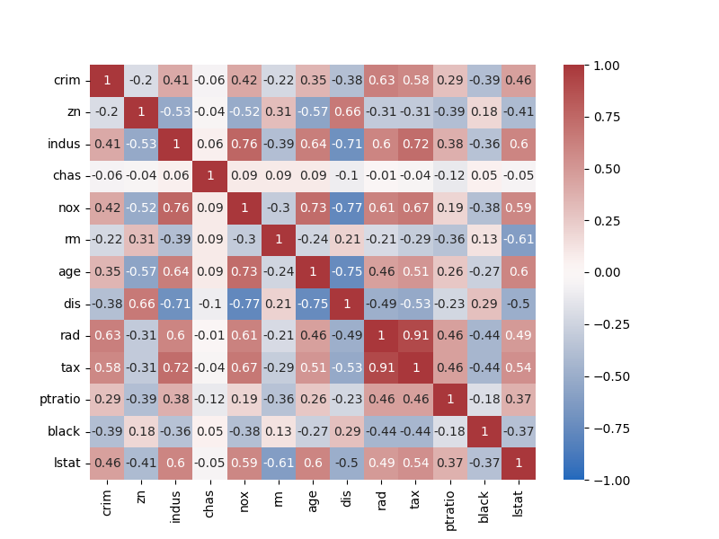

```python
corrmat(boston_df, 'medv')
```

#### Interprete the results.

It is obvious that the linear regression model is impaired due to strong correlation between the variables.

The weakest correlation is between `chas` and other variables. The strongest correlation is between `tax` and `rad` (positive). Other strong correlations include:

- positive: `indus` & `nox`, `indus` & `tax`, `nox` & `age`;
- negative: `indus` & `dis`, `nox` & `dis`, `age` & `dis`;

It has to be noted that the `age` variable has strong correlation with other variables, which confirms the large $p\:value$ for age during the Linear Regression `medv~lstat+rm+age` (see the interpretation above).

### 1.2.5 Use the multiple linear regression model

Predict the `medv` response values for some selected predictor values. Calculate the prediction intervals for these values.

```python
lstat_x=pd.Series((5,10,15), name='lstat')
rm_x=pd.Series((5,6.5,8), name='rm')
X = pd.merge(lstat_x, rm_x, how='cross')

lstat_rm_mod_fit = ols('medv~lstat+rm', boston_df).fit()
display(Markdown('#### Prediction:'), predict_with_pi(lstat_rm_mod_fit, X, ylab='medv'))
display(Markdown('#### Axes Data Described:'), describe_axes(boston_df[['lstat', 'rm']], boston_df['medv']))
```

Prediction:

| lstat+rm | medv | medv_lwr | medv_upr |
| --- | --- | --- | --- |
| 5.0; 5.0 | 20.903875 | 9.889729 | 31.918021 |
| 5.0; 6.5 | 28.546057 | 17.635923 | 39.456192 |
| 5.0; 8.0 | 36.188239 | 25.225479 | 47.150999 |
| 10.0; 5.0 | 17.692084 | 6.722152 | 28.662016 |
| 10.0; 6.5 | 25.334266 | 14.437027 | 36.231505 |
| 10.0; 8.0 | 32.976448 | 21.995024 | 43.957872 |
| 15.0; 5.0 | 14.480292 | 3.537875 | 25.422709 |
| 15.0; 6.5 | 22.122474 | 11.221204 | 33.023745 |
| 15.0; 8.0 | 29.764656 | 18.747835 | 40.781477 |

Axes Data Described:

|  | lstat | rm | medv |
| --- | --- | --- | --- |
| count | 506.000000 | 506.000000 | 506.000000 |
| mean | 12.653063 | 6.284634 | 22.532806 |
| std | 7.141062 | 0.702617 | 9.197104 |
| min | 1.730000 | 3.561000 | 5.000000 |
| 25% | 6.950000 | 5.885500 | 17.025000 |
| 50% | 11.360000 | 6.208500 | 21.200000 |
| 75% | 16.955000 | 6.623500 | 25.000000 |
| max | 37.970000 | 8.780000 | 50.000000 |
| max - min | 36.240000 | 5.219000 | 45.000000 |

#### Interprete the results.

The regression results with prediction interval have to be analyzed together with the data about the `medv` axis.

The prediction interval is around 21 - 22 which is less than it was for single-variable linear regression. This means that multiple-variable linear regression makes more sense in this context since the prediction by the single linear regression had slightly larger intervals.